# Actividad # 1 IAM

Jhonatan Smith Garcia c.c 1039705595

Abril, 2022

```r
library(tidyverse)
data = iris
names(data)
```

```
## [1] "Sepal.Length" "Sepal.Width"  "Petal.Length" "Petal.Width"  "Species"
```

```r
attach(data)
```

La base de datos a trabajar tiene 5 variables, de las cuales describen brevemente la longitud y amplotud de petalo y sepalo de las flores iris. Tambien, la variable “species” indica obviamente la especie de la flor. Esta ultima variable es categorica.

```r
levels(Species)
```

```
## [1] "setosa"     "versicolor" "virginica"
```

Estos son los 3 niveles de la variable especie. Es decir, las especies que se tienen tabuladas y muestreadas.

La muestra es de tamaño 150.

```r
data %>% nrow()
```

```
## [1] 150
```

Entonces, se tiene una base de datos con informacion de jun tipo de flor iris, la longitudes de sus petalos, sepalos, la anchura de los mismos y finalmente, el tipo de flor. Dicha base de datos cumple los parametros establecitos para el presente trabajo.

```r
head(data)
```

```
##   Sepal.Length Sepal.Width Petal.Length Petal.Width Species
## 1          5.1         3.5          1.4         0.2  setosa
## 2          4.9         3.0          1.4         0.2  setosa
## 3          4.7         3.2          1.3         0.2  setosa
## 4          4.6         3.1          1.5         0.2  setosa
## 5          5.0         3.6          1.4         0.2  setosa
## 6          5.4         3.9          1.7         0.4  setosa
```

Los datos tienen esta estructura general.

Ahora, observe la estructura de los datos.

```r
str(data)
```

```
## 'data.frame':    150 obs. of  5 variables:
##  $ Sepal.Length: num  5.1 4.9 4.7 4.6 5 5.4 4.6 5 4.4 4.9 ...
##  $ Sepal.Width : num  3.5 3 3.2 3.1 3.6 3.9 3.4 3.4 2.9 3.1 ...
##  $ Petal.Length: num  1.4 1.4 1.3 1.5 1.4 1.7 1.4 1.5 1.4 1.5 ...
##  $ Petal.Width : num  0.2 0.2 0.2 0.2 0.2 0.4 0.3 0.2 0.2 0.1 ...
##  $ Species     : Factor w/ 3 levels "setosa","versicolor",..: 1 1 1 1 1 1 1 1 1 1 ...
```

Es un data frame con 4 varuables numericas y una categorica.

Una aproximacion general al comportamiento de los datos lo da la funcion summary.

```r
summary(data)
```

```
##   Sepal.Length    Sepal.Width     Petal.Length    Petal.Width
##  Min.   :4.300   Min.   :2.000   Min.   :1.000   Min.   :0.100
##  1st Qu.:5.100   1st Qu.:2.800   1st Qu.:1.600   1st Qu.:0.300
##  Median :5.800   Median :3.000   Median :4.350   Median :1.300
##  Mean   :5.843   Mean   :3.057   Mean   :3.758   Mean   :1.199
##  3rd Qu.:6.400   3rd Qu.:3.300   3rd Qu.:5.100   3rd Qu.:1.800
##  Max.   :7.900   Max.   :4.400   Max.   :6.900   Max.   :2.500
##        Species
##  setosa    :50
##  versicolor:50
##  virginica :50
##
##
##
```

Aqui, para cada variable, se tiene una media, una mediana, minimo, maximo.

Asi por ejemplo, la longitud promedio de sepalo es de 5.843 Ahora, esto en general, para todas las flores. Sin hacer distinciones.

*Vector de medias, matriz de varianza y covarianza*

```r
media <- colMeans(data[1:4])
media
```

```
## Sepal.Length  Sepal.Width Petal.Length  Petal.Width
##     5.843333     3.057333     3.758000     1.199333
```

Este es el vector de medias de los datos.

```r
# Matriz de varianzas y covarianza

covarianza <- cov(data[1:4])
covarianza
```

```
##              Sepal.Length Sepal.Width Petal.Length Petal.Width
## Sepal.Length    0.6856935  -0.0424340    1.2743154   0.5162707
## Sepal.Width    -0.0424340   0.1899794   -0.3296564  -0.1216394
## Petal.Length    1.2743154  -0.3296564    3.1162779   1.2956094
## Petal.Width     0.5162707  -0.1216394    1.2956094   0.5810063
```

La diagonal principal es la varianza de los datos. Aqui estan las covarianzas de todos los datos.

```r
# Matriz de correlacion

correlacion <- cor(data[1:4])
correlacion
```

```
##              Sepal.Length Sepal.Width Petal.Length Petal.Width
## Sepal.Length    1.0000000  -0.1175698    0.8717538   0.8179411
## Sepal.Width    -0.1175698   1.0000000   -0.4284401  -0.3661259
## Petal.Length    0.8717538  -0.4284401    1.0000000   0.9628654
## Petal.Width     0.8179411  -0.3661259    0.9628654   1.0000000
```

Algunos tienen correlacion negativas. Esto tiene sentido puesto que, la longitud de las hojas de un iris, en general; no es igual a la amplitud. Esto, dado la naturaleza de la flor. Entonces dichas correlaciones tienen sentido entre si.

Ahora, esta relacion se hace cuando tenga sentido commparar el amplitud del sepalo y petalo, asi como su longitud.

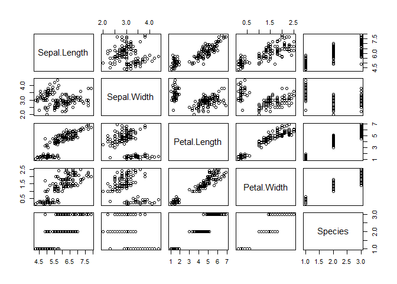

```r
plot(data)
```

Cabe notar que si se encuentran patrones apreciables en algunos casos. Donde si se tiene sentido hacer comparaciones. Por ejemplo, la longitud del peralo con la amplitud del petalo. Estos estan relacionados pero, tendra relacion la longitud del pedalo con la amplitud del sepalo? EN el grafico no se logra aprecias algo fuerte.

Ahora, Al categorizar por especies, si se puede percibir una media por estas. entonces:

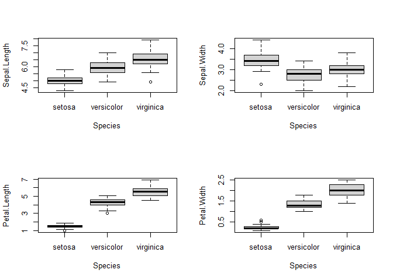

```r
par(mfrow=c(2,2))
boxplot(Sepal.Length~Species)
boxplot(Sepal.Width~Species)
boxplot(Petal.Length~Species)
boxplot(Petal.Width~Species)
```

Claramente, existe diferencia de la media de cada variable al categorizarlos por especies.Por ejemplo, la virginica tiene una anchura de petalo mas grande que el resto (en promedio), al igual que la longitud de su petalo. Por otra parte, la setosa en general parece mas pequeña sin embargo, es la que tiene un sepalo mas ancho.

Analicemos la normalidad de los datos para cada variable.

```r
library(car)
```

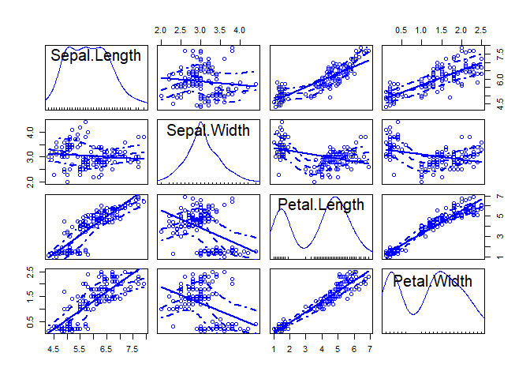

```r
scatterplotMatrix(data[1:4])
```

Pareciese que los unicos que tienden a ser normales (puesto que medio parece una campana) es la anchura del sepalo. A la recta de normalidad, dificilmente se acercan los datos.

Analicemos uno a uno.

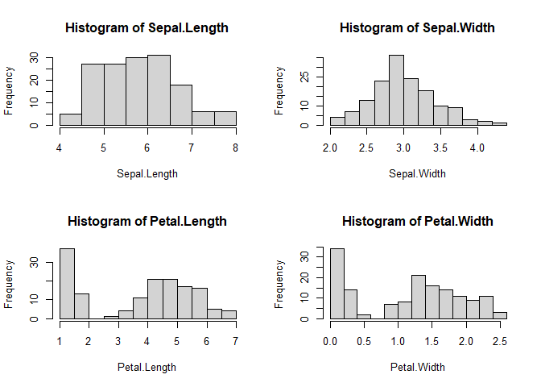

```r
par(mfrow =c(2,2))
hist(Sepal.Length)
hist(Sepal.Width)
hist(Petal.Length)
hist(Petal.Width)
```

En efecto, parecesiese que la amplitud del sepalo es el unico que distribuye normal. Los otros, no parecen tener esta tendencia.

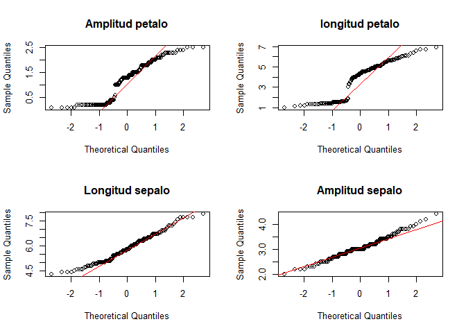

```r
par(mfrow=c(2,2))
qqnorm(Petal.Width, main = "Amplitud petalo")
qqline(Petal.Width, col = "red")

qqnorm(Petal.Length, main = "longitud petalo")
qqline(Petal.Length, col = "red")

qqnorm(Sepal.Length, main = "Longitud sepalo")
qqline(Sepal.Length, col = "red")


qqnorm(Sepal.Width, main = "Amplitud sepalo")
qqline(Sepal.Width, col = "red")
```

Nuevamente, parece que los unicos datos que distribuyen normal son la amplitud de sepalo.